# Red wine (Vinho Verde) quality exploration by Sebastien LOPATOWSKI

# Multivariate Analysis

### Talk about some of the relationships you observed in this part of the investigation. Were there features that strengthened each other in terms of looking at your feature(s) of interest?

The residual sugar with few chlorides give a good quality of wine. Moreover, the volatile.acidity (less than 0.8) give also a good wine quality.

### Were there any interesting or surprising interactions between features?

It is not clearly evident that the density is linked to the residual sugar and alcohol.

### OPTIONAL: Did you create any models with your dataset? Discuss the strengths and limitations of your model.

# Final Plots and Summary

### Plot One

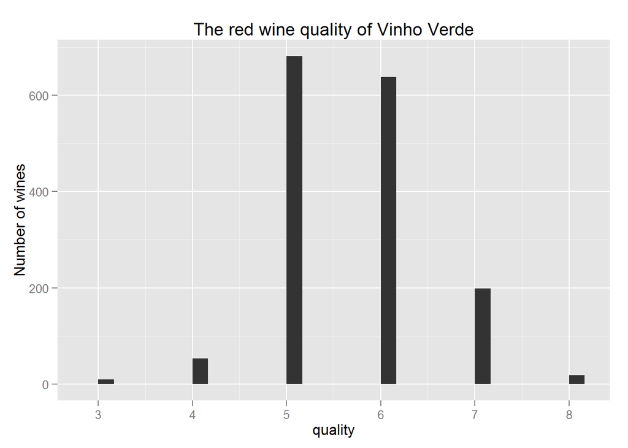

### Description One

The red wine quality of Vinho Verde is quite correct. The most number of wines is around 5, 6 and 7.

### Plot Two

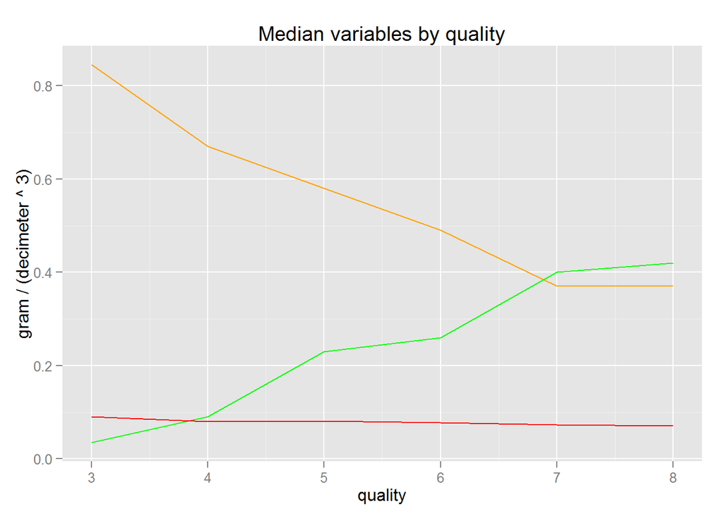

### Plot Three

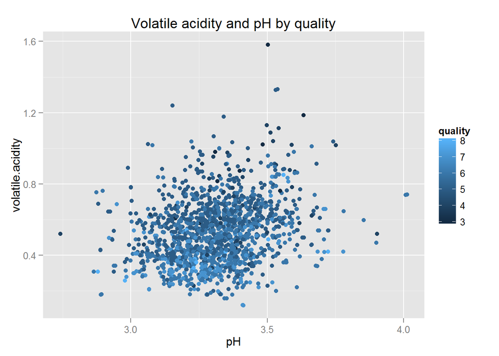

### Description Three

# Reflection

The red wine data set contains information on almost 1600 Vinho Verde wines. I started by understanding the individual variables in the data set, and then I explored interesting questions and leads as I continued to make observations on plots. Eventually, I explored the quality of wines across many variables to find some correlation. I was surprised that some variables did not have a strong correlation with quality. I struggled understanding to find a clearly variables which explain the red wine quality. Maybe it’s due to the quality score (median of at least 3 evaluations made by wine experts) which are subjective because each person have own preferences in term of taste. Also, a data with more observations would be better to make predictions of red wine Vinho Verde quality.